# Portfolio assignment 3

15 min: Perform a univariate analysis on all the categorical data of the penguins dataset. Commit the notebook to your portfolio when you're finished. Optional: Start working on portfolio assignment 4

```python
import pandas as pd
```

```python
import seaborn as sns
```

```python
penguins = sns.load_dataset("penguins")
```

```python
penguins
```

|  | species | island | bill_length_mm | bill_depth_mm | flipper_length_mm | body_mass_g | sex |
| --- | --- | --- | --- | --- | --- | --- | --- |
| 0 | Adelie | Torgersen | 39.1 | 18.7 | 181.0 | 3750.0 | Male |
| 1 | Adelie | Torgersen | 39.5 | 17.4 | 186.0 | 3800.0 | Female |
| 2 | Adelie | Torgersen | 40.3 | 18.0 | 195.0 | 3250.0 | Female |
| 3 | Adelie | Torgersen | NaN | NaN | NaN | NaN | NaN |
| 4 | Adelie | Torgersen | 36.7 | 19.3 | 193.0 | 3450.0 | Female |
| ... | ... | ... | ... | ... | ... | ... | ... |
| 339 | Gentoo | Biscoe | NaN | NaN | NaN | NaN | NaN |
| 340 | Gentoo | Biscoe | 46.8 | 14.3 | 215.0 | 4850.0 | Female |
| 341 | Gentoo | Biscoe | 50.4 | 15.7 | 222.0 | 5750.0 | Male |
| 342 | Gentoo | Biscoe | 45.2 | 14.8 | 212.0 | 5200.0 | Female |
| 343 | Gentoo | Biscoe | 49.9 | 16.1 | 213.0 | 5400.0 | Male |

344 rows × 7 columns

```python
penguins.columns
```

```
Index(['species', 'island', 'bill_length_mm', 'bill_depth_mm',
       'flipper_length_mm', 'body_mass_g', 'sex'],
      dtype='object')
```

### Sex

```python
penguins['sex'].unique()
```

```
array(['Male', 'Female', nan], dtype=object)
```

```python
penguins['sex'].value_counts()
```

```
Male      168
Female    165
Name: sex, dtype: int64
```

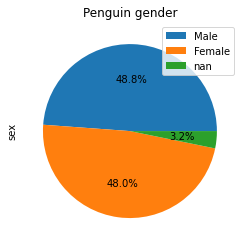

```python
penguins['sex'].value_counts(dropna=False).plot(kind='pie', title='Penguin gender', legend=True, labels=None, autopct='%1.1f%%')
```

### Species

```python
penguins['species'].unique()
```

```
array(['Adelie', 'Chinstrap', 'Gentoo'], dtype=object)
```

```python
penguins['species'].value_counts()
```

```
Adelie       152
Gentoo       124
Chinstrap     68
Name: species, dtype: int64
```

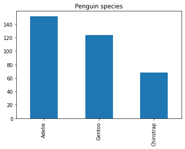

```python
penguins['species'].value_counts().plot(kind='bar', title='Penguin species')
```

### Island

```python
penguins['island'].unique()
```

```
array(['Torgersen', 'Biscoe', 'Dream'], dtype=object)
```

```python
penguins['island'].value_counts()
```

```
Biscoe       168
Dream        124
Torgersen     52
Name: island, dtype: int64
```

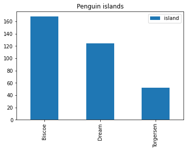

```python
penguins['island'].value_counts().plot(kind='bar', title='Penguin islands', legend= True)
```

### Bill length mm

```python
penguins['bill_length_mm'].unique()
```

```
array([39.1, 39.5, 40.3,  nan, 36.7, 39.3, 38.9, 39.2, 34.1, 42. , 37.8,
       41.1, 38.6, 34.6, 36.6, 38.7, 42.5, 34.4, 46. , 37.7, 35.9, 38.2,
       38.8, 35.3, 40.6, 40.5, 37.9, 37.2, 40.9, 36.4, 42.2, 37.6, 39.8,
       36.5, 40.8, 36. , 44.1, 37. , 39.6, 37.5, 42.3, 40.1, 35. , 34.5,
       41.4, 39. , 35.7, 41.3, 41.6, 35.5, 41.8, 33.5, 39.7, 45.8, 42.8,
       36.2, 42.1, 42.9, 35.1, 37.3, 36.3, 36.9, 38.3, 34. , 38.1, 33.1,
       43.2, 41. , 45.6, 42.7, 40.2, 35.2, 41.5, 38.5, 43.1, 36.8, 35.6,
       32.1, 40.7, 46.5, 50. , 51.3, 45.4, 52.7, 45.2, 46.1, 46.6, 51.7,
       47. , 52. , 45.9, 50.5, 50.3, 58. , 46.4, 49.2, 42.4, 48.5, 50.6,
       46.7, 49.5, 52.8, 54.2, 51. , 49.7, 47.5, 47.6, 46.9, 53.5, 49. ,
       46.2, 50.9, 45.5, 50.8, 50.1, 51.5, 49.8, 48.1, 51.4, 45.7, 50.7,
       52.2, 49.3, 50.2, 51.9, 46.8, 55.8, 43.5, 49.6, 48.7, 43.3, 48.4,
       45.1, 46.3, 44.5, 47.8, 48.2, 47.3, 59.6, 49.1, 42.6, 44.4, 44. ,
       45.3, 43.6, 44.9, 45. , 43.8, 50.4, 54.3, 47.7, 48.6, 51.1, 52.5,
       47.4, 43.4, 52.1, 49.4, 55.9, 47.2, 41.7, 53.4, 55.1, 48.8, 49.9])
```

```python
penguins['bill_length_mm'].value_counts()
```

```
41.1    7
45.2    6
39.6    5
37.8    5
46.5    5
       ..
45.9    1
42.4    1
55.1    1
52.7    1
51.9    1
Name: bill_length_mm, Length: 164, dtype: int64
```

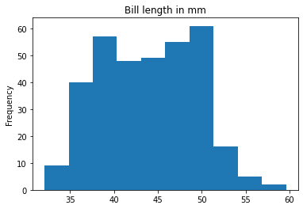

```python
penguins['bill_length_mm'].plot(kind='hist', title='Bill length in mm')
```

### Bill depth mm

```python
penguins['bill_depth_mm'].unique()
```

```
array([18.7, 17.4, 18. ,  nan, 19.3, 20.6, 17.8, 19.6, 18.1, 20.2, 17.1,
       17.3, 17.6, 21.2, 21.1, 19. , 20.7, 18.4, 21.5, 18.3, 19.2, 17.2,
       18.9, 18.6, 17.9, 16.7, 17. , 20. , 18.5, 19.1, 19.7, 16.9, 18.8,
       17.7, 19.5, 17.5, 16.6, 18.2, 16.2, 19.4, 16.8, 16.1, 20.3, 16. ,
       16.5, 20.5, 19.8, 15.9, 20.1, 15.5, 19.9, 20.8, 16.4, 13.2, 16.3,
       14.1, 15.2, 14.5, 13.5, 14.6, 15.3, 13.4, 15.4, 13.7, 15.7, 15.1,
       14.3, 15.8, 13.1, 15. , 14.2, 14.8, 13.6, 13.9, 13.3, 14.4, 13.8,
       14.9, 15.6, 14. , 14.7])
```

```python
penguins['bill_depth_mm'].value_counts()
```

```
17.0    12
18.6    10
15.0    10
18.5    10
17.9    10
        ..
20.8     1
13.4     1
17.4     1
20.6     1
13.3     1
Name: bill_depth_mm, Length: 80, dtype: int64
```

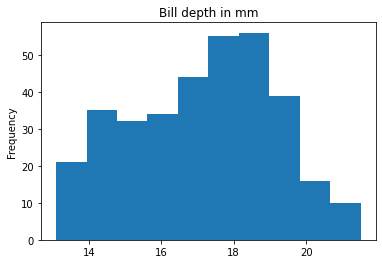

```python
penguins['bill_depth_mm'].plot(kind='hist', title='Bill depth in mm')
```

### Flipper length mm

```python
penguins['flipper_length_mm'].unique()
```

```
array([181., 186., 195.,  nan, 193., 190., 180., 182., 191., 198., 185.,
       197., 184., 194., 174., 189., 187., 183., 172., 178., 188., 196.,
       179., 200., 192., 202., 205., 208., 203., 199., 176., 210., 201.,
       212., 206., 207., 211., 230., 218., 215., 219., 209., 214., 216.,
       213., 217., 221., 222., 220., 225., 224., 231., 229., 223., 228.,
       226.])
```

```python
penguins['flipper_length_mm'].value_counts()
```

```
190.0    22
195.0    17
187.0    16
193.0    15
210.0    14
191.0    13
215.0    12
196.0    10
197.0    10
185.0     9
216.0     8
208.0     8
198.0     8
220.0     8
181.0     7
186.0     7
192.0     7
230.0     7
184.0     7
189.0     7
212.0     7
188.0     6
199.0     6
217.0     6
201.0     6
213.0     6
222.0     6
214.0     6
180.0     5
194.0     5
203.0     5
219.0     5
221.0     5
209.0     5
218.0     5
202.0     4
228.0     4
178.0     4
225.0     4
200.0     4
205.0     3
224.0     3
182.0     3
223.0     2
229.0     2
211.0     2
207.0     2
183.0     2
174.0     1
206.0     1
176.0     1
231.0     1
172.0     1
179.0     1
226.0     1
Name: flipper_length_mm, dtype: int64
```

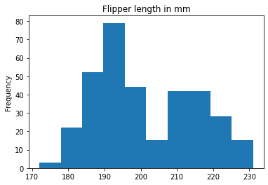

```python
penguins['flipper_length_mm'].plot(kind='hist', title='Flipper length in mm')
```

### Body mass g

```python
penguins['body_mass_g'].unique()
```

```
array([3750., 3800., 3250.,   nan, 3450., 3650., 3625., 4675., 3475.,
       4250., 3300., 3700., 3200., 4400., 4500., 3325., 4200., 3400.,
       3600., 3950., 3550., 3150., 3900., 4150., 4650., 3100., 3000.,
       4600., 3425., 2975., 3500., 4300., 4050., 2900., 2850., 3350.,
       4100., 3050., 4450., 4000., 4700., 4350., 3725., 4725., 3075.,
       2925., 3175., 4775., 3825., 4275., 4075., 3775., 3875., 3275.,
       4475., 3975., 3525., 3575., 4550., 3850., 4800., 2700., 3675.,
       5700., 5400., 5200., 5150., 5550., 5850., 6300., 5350., 5000.,
       5050., 5100., 5650., 5250., 6050., 4950., 4750., 4900., 5300.,
       4850., 5800., 6000., 5950., 4625., 5450., 5600., 4875., 4925.,
       4975., 5500., 4575., 4375., 5750.])
```

```python
penguins['body_mass_g'].value_counts()
```

```
3800.0    12
3700.0    11
3950.0    10
3900.0    10
3550.0     9
          ..
4975.0     1
4275.0     1
3100.0     1
3275.0     1
4775.0     1
Name: body_mass_g, Length: 94, dtype: int64
```

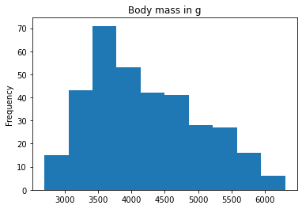

```python
penguins['body_mass_g'].plot(kind='hist',title='Body mass in g', bins=10)
```

```python
penguins.isna().sum()
```

```
species               0
island                0
bill_length_mm        2
bill_depth_mm         2
flipper_length_mm     2
body_mass_g           2
sex                  11
dtype: int64
```

# Portfolio assignment 4

15 min: Look online for a datset that you personally find interesting to explore. It can be about any topic that you find interesting: sports, games, software development, etc. Commit the dataset to your portfolio. You will be analysing the dataset in future portfolio assignments.

Required characteristics of the dataset:

- Must be in a tabular format: Contains rows and columns
- Contains at least 100 rows
- Contains at least 2 columns with categorical data and at least 2 columns with numerical data
- Is less than 200 MB

#### Gekozen dataset: Movies

aantal kolommen: 20

aantal rijen: 4803

5.43 mbs

2 voorbeelden van categorical data: genres en original_language

2 voorbeelden van numerical data: runtime en vote_average

```python
import pandas as pd

movies = pd.read_csv (r'movies.csv')
```

```python
len(movies.columns)
```

```
20
```

```python
len(movies)
```

```
4803
```

```python
movies.columns
```

```
Index(['budget', 'genres', 'homepage', 'id', 'keywords', 'original_language',
       'original_title', 'overview', 'popularity', 'production_companies',
       'production_countries', 'release_date', 'revenue', 'runtime',
       'spoken_languages', 'status', 'tagline', 'title', 'vote_average',
       'vote_count'],
      dtype='object')
```

# Portfolio assignment 5

20 min:

- Download lifeExpectancyAtBirth.csv from Onderwijsmateriaal/Datasets on Blackboard.
- Move the file to the same folder as the Notebook that you will be working in.
- Load the dataset in your Notebook with the following code: lifeExpectancy = pd.read_csv('Datasets/lifeExpectancyAtBirth.csv', sep=',')
- Look at the dataset with the .head() function.
- Filter the dataframe: We only want the life expectancy data about 2019 and 'Both sexes'
- Use this dataframe to perform a univariate analysis on the life expectancy in 2019.

Commit the notebook and dataset to your portfolio when you're finished.

```python
lifeExpectancy = pd.read_csv('lifeExpectancyAtBirth.csv', sep=',')
```

```python
lifeExpectancy.head()
```

|  | Location | Period | Indicator | Dim1 | First Tooltip |
| --- | --- | --- | --- | --- | --- |
| 0 | Afghanistan | 2019 | Life expectancy at birth (years) | Both sexes | 63.21 |
| 1 | Afghanistan | 2019 | Life expectancy at birth (years) | Male | 63.29 |
| 2 | Afghanistan | 2019 | Life expectancy at birth (years) | Female | 63.16 |
| 3 | Afghanistan | 2015 | Life expectancy at birth (years) | Both sexes | 61.65 |
| 4 | Afghanistan | 2015 | Life expectancy at birth (years) | Male | 61.04 |

```python
lifeExpectancy.columns
```

```
Index(['Location', 'Period', 'Indicator', 'Dim1', 'First Tooltip'], dtype='object')
```

```python
import pandas as pd
```

```python
filtered =  lifeExpectancy.query('Dim1=="Both sexes" & Period=="2019" ')
```

```python
print(filtered.head())
```

```
               Location  Period                         Indicator        Dim1  \
0           Afghanistan    2019  Life expectancy at birth (years)  Both sexes
12              Albania    2019  Life expectancy at birth (years)  Both sexes
24              Algeria    2019  Life expectancy at birth (years)  Both sexes
36               Angola    2019  Life expectancy at birth (years)  Both sexes
48  Antigua and Barbuda    2019  Life expectancy at birth (years)  Both sexes

    First Tooltip
0           63.21
12          78.00
24          77.13
36          63.06
48          76.45
```

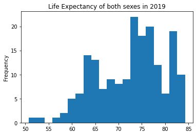

```python
filtered['First Tooltip'].plot(kind='hist', title='Life Expectancy of both sexes in 2019', bins=20)
```

Gemiddelde leeftijd

```python
round(filtered["First Tooltip"].mean(), 1)
```

```
72.5
```

Land met hoogste levensverwachting & land met laagste levensverwachting

```python
filtered[filtered["First Tooltip"] == filtered["First Tooltip"].max()]
```

|  | Location | Period | Indicator | Dim1 | First Tooltip |
| --- | --- | --- | --- | --- | --- |
| 997 | Japan | 2019 | Life expectancy at birth (years) | Both sexes | 84.26 |

```python
filtered[filtered["First Tooltip"] == filtered["First Tooltip"].min()]
```

|  | Location | Period | Indicator | Dim1 | First Tooltip |
| --- | --- | --- | --- | --- | --- |
| 1117 | Lesotho | 2019 | Life expectancy at birth (years) | Both sexes | 50.75 |

Top 5 landen met laagste en hoogste life expectancy

```python
filtered.sort_values(by="First Tooltip")
```

|  | Location | Period | Indicator | Dim1 | First Tooltip |
| --- | --- | --- | --- | --- | --- |
| 1117 | Lesotho | 2019 | Life expectancy at birth (years) | Both sexes | 50.75 |
| 373 | Central African Republic | 2019 | Life expectancy at birth (years) | Both sexes | 53.10 |
| 1801 | Somalia | 2019 | Life expectancy at birth (years) | Both sexes | 56.47 |
| 661 | Eswatini | 2019 | Life expectancy at birth (years) | Both sexes | 57.73 |
| 1333 | Mozambique | 2019 | Life expectancy at birth (years) | Both sexes | 58.14 |
| ... | ... | ... | ... | ... | ... |
| 1837 | Spain | 2019 | Life expectancy at birth (years) | Both sexes | 83.22 |
| 1753 | Singapore | 2019 | Life expectancy at birth (years) | Both sexes | 83.22 |
| 1573 | Republic of Korea | 2019 | Life expectancy at birth (years) | Both sexes | 83.30 |
| 1897 | Switzerland | 2019 | Life expectancy at birth (years) | Both sexes | 83.45 |
| 997 | Japan | 2019 | Life expectancy at birth (years) | Both sexes | 84.26 |

183 rows × 5 columns

Mediaan van alle landen

```python
filtered["First Tooltip"].median()
```

```
73.74
```

Standard deviation

```python
round(filtered["First Tooltip"].std(),1)
```

```
7.1
```

Boxplot van levensverwachting

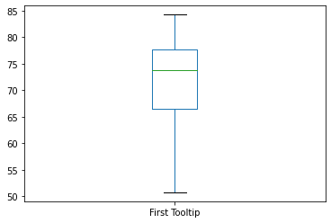

```python
filtered["First Tooltip"].plot(kind="box")
```

Histogram van levensverwachting

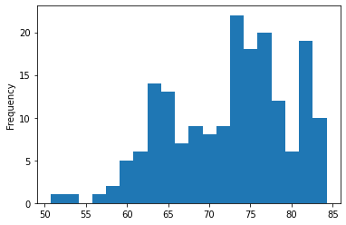

```python
filtered["First Tooltip"].plot(kind="hist", bins=20)
```

# Portfolio assignment 6

60 min: Perform a univariate analysis on at least 2 columns with categorical data and on at least 2 columns with numerical data in the dataset that you chose in portfolio assignment 4. Commit the Notebook to your portfolio when you're finished.

```python
import pandas as pd

movies = pd.read_csv (r'movies.csv')
```

```python
movies.columns
```

```
Index(['budget', 'genres', 'homepage', 'id', 'keywords', 'original_language',
       'original_title', 'overview', 'popularity', 'production_companies',
       'production_countries', 'release_date', 'revenue', 'runtime',
       'spoken_languages', 'status', 'tagline', 'title', 'vote_average',
       'vote_count'],
      dtype='object')
```

### Original Language

```python
movies['original_language'].unique()
```

```
array(['en', 'ja', 'fr', 'zh', 'es', 'de', 'hi', 'ru', 'ko', 'te', 'cn',
       'it', 'nl', 'ta', 'sv', 'th', 'da', 'xx', 'hu', 'cs', 'pt', 'is',
       'tr', 'nb', 'af', 'pl', 'he', 'ar', 'vi', 'ky', 'id', 'ro', 'fa',
       'no', 'sl', 'ps', 'el'], dtype=object)
```

```python
movies['original_language'].value_counts()
```

```
en    4505
fr      70
es      32
de      27
zh      27
hi      19
ja      16
it      14
cn      12
ru      11
ko      11
pt       9
da       7
sv       5
nl       4
fa       4
he       3
th       3
ro       2
cs       2
ta       2
ar       2
id       2
af       1
xx       1
sl       1
no       1
nb       1
pl       1
is       1
ps       1
ky       1
vi       1
el       1
te       1
hu       1
tr       1
Name: original_language, dtype: int64
```

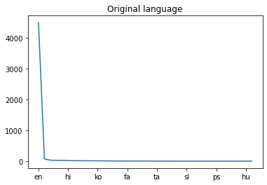

```python
movies['original_language'].value_counts().plot(kind='line', title='Original language')
```

### Status

```python
movies['status'].unique()
```

```
array(['Released', 'Post Production', 'Rumored'], dtype=object)
```

```python
movies['status'].value_counts()
```

```
Released           4795
Rumored               5
Post Production       3
Name: status, dtype: int64
```

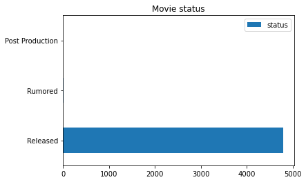

```python
movies['status'].value_counts().plot(kind='barh', title='Movie status', legend= True)
```

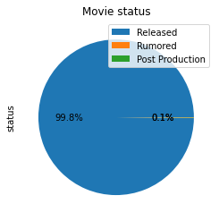

```python
movies['status'].value_counts().plot(kind='pie', title='Movie status',  legend=True, labels=None, autopct='%1.1f%%')
```

### Runtime

```python
column = 'runtime'
```

Kortste afspeelduur

```python
movies[column].min()
```

```
0.0
```

Langste afspeelduur

```python
movies[column].max()
```

```
338.0
```

Gemiddelde afspeelduur

```python
round(movies[column].mean())
```

```
107
```

Mediaan van afspeelduur (middelste)

```python
round(movies[column].median())
```

```
103
```

Standaard afwijking

```python
round(movies[column].std())
```

```
23
```

Film(s) met de langste afspeelduur

```python
movies[movies[column] == movies[column].max()]
```

|  | budget | genres | homepage | id | keywords | original_language | original_title | overview | popularity | production_companies | production_countries | release_date | revenue | runtime | spoken_languages | status | tagline | title | vote_average | vote_count |
| --- | --- | --- | --- | --- | --- | --- | --- | --- | --- | --- | --- | --- | --- | --- | --- | --- | --- | --- | --- | --- |
| 2384 | 18000000 | [{"id": 80, "name": "Crime"}, {"id": 18, "name... | NaN | 43434 | [{"id": 1419, "name": "gun"}, {"id": 7336, "na... | en | Carlos | The story of Venezuelan revolutionary, Ilich R... | 1.138383 | [{"name": "Egoli Tossell Film AG", "id": 2254}... | [{"iso_3166_1": "FR", "name": "France"}, {"iso... | 2010-05-19 | 871279 | 338.0 | [{"iso_639_1": "fr", "name": "Fran\u00e7ais"},... | Released | The man who hijacked the world | Carlos | 6.7 | 50 |

Film(s) met de kortste afspeelduur

```python
movies[movies[column] == movies[column].min()]
```

|  | budget | genres | homepage | id | keywords | original_language | original_title | overview | popularity | production_companies | production_countries | release_date | revenue | runtime | spoken_languages | status | tagline | title | vote_average | vote_count |
| --- | --- | --- | --- | --- | --- | --- | --- | --- | --- | --- | --- | --- | --- | --- | --- | --- | --- | --- | --- | --- |
| 1011 | 0 | [{"id": 27, "name": "Horror"}] | NaN | 53953 | [{"id": 10292, "name": "gore"}, {"id": 12339, ... | de | The Tooth Fairy | A woman and her daughter (Nicole Muñoz) encoun... | 0.716764 | [] | [] | 2006-08-08 | 0 | 0.0 | [{"iso_639_1": "en", "name": "English"}, {"iso... | Released | NaN | The Tooth Fairy | 4.3 | 13 |
| 3112 | 0 | [{"id": 18, "name": "Drama"}, {"id": 80, "name... | NaN | 41894 | [] | en | Blood Done Sign My Name | A drama based on the true story in which a bla... | 0.397341 | [] | [] | 2010-02-01 | 0 | 0.0 | [] | Released | No one changes the world alone. | Blood Done Sign My Name | 6.0 | 5 |
| 3669 | 0 | [{"id": 35, "name": "Comedy"}, {"id": 18, "nam... | http://www.romeothemovie.com/ | 113406 | [] | en | Should've Been Romeo | A self-centered, middle-aged pitchman for a po... | 0.407030 | [{"name": "Phillybrook Films", "id": 65147}] | [{"iso_3166_1": "US", "name": "United States o... | 2012-04-28 | 0 | 0.0 | [{"iso_639_1": "en", "name": "English"}] | Released | Even Shakespeare didn't see this one coming. | Should've Been Romeo | 0.0 | 0 |
| 3809 | 4000000 | [{"id": 35, "name": "Comedy"}, {"id": 10749, "... | NaN | 158150 | [] | en | How to Fall in Love | An accountant, who never quite grew out of his... | 1.923514 | [{"name": "Annuit Coeptis Entertainment Inc.",... | [{"iso_3166_1": "US", "name": "United States o... | 2012-07-21 | 0 | 0.0 | [{"iso_639_1": "en", "name": "English"}] | Released | NaN | How to Fall in Love | 5.2 | 20 |
| 3953 | 0 | [{"id": 10752, "name": "War"}, {"id": 18, "nam... | NaN | 281230 | [{"id": 187056, "name": "woman director"}] | en | Fort McCoy | Unable to serve in World War II because of a h... | 0.384496 | [] | [] | 2014-01-01 | 0 | 0.0 | [] | Released | NaN | Fort McCoy | 6.3 | 2 |
| 3992 | 0 | [] | NaN | 346081 | [] | en | Sardaarji | A ghost hunter uses bottles to capture trouble... | 0.296981 | [] | [{"iso_3166_1": "IN", "name": "India"}] | 2015-06-26 | 0 | 0.0 | [] | Released | NaN | Sardaarji | 9.5 | 2 |
| 4068 | 0 | [] | NaN | 371085 | [] | en | Sharkskin | The Post War II story of Manhattan born Mike E... | 0.027801 | [] | [] | 2015-01-01 | 0 | 0.0 | [] | Released | NaN | Sharkskin | 0.0 | 0 |
| 4118 | 0 | [] | NaN | 325140 | [] | en | Hum To Mohabbat Karega | Raju, a waiter, is in love with the famous TV ... | 0.001186 | [] | [] | 2000-05-26 | 0 | 0.0 | [] | Released | NaN | Hum To Mohabbat Karega | 0.0 | 0 |
| 4205 | 0 | [{"id": 18, "name": "Drama"}, {"id": 80, "name... | http://www.imdb.com/title/tt1289419/ | 66468 | [] | en | N-Secure | N-Secure is a no holds-barred thrilling drama ... | 0.134560 | [] | [] | 2010-10-15 | 2592808 | 0.0 | [] | Released | NaN | N-Secure | 4.3 | 4 |
| 4210 | 0 | [{"id": 10749, "name": "Romance"}] | NaN | 74084 | [] | hi | दिल जो भी कहे | During the British rule in India, several Indi... | 0.122704 | [{"name": "Entertainment One Pvt. Ltd.", "id":... | [{"iso_3166_1": "IN", "name": "India"}] | 2006-12-07 | 0 | 0.0 | [{"iso_639_1": "en", "name": "English"}, {"iso... | Released | NaN | Dil Jo Bhi Kahey... | 0.0 | 0 |
| 4241 | 1500000 | [{"id": 35, "name": "Comedy"}] | NaN | 51820 | [{"id": 10183, "name": "independent film"}] | en | The Salon | A Beauty shop owner finds romance as she strug... | 2.028170 | [] | [] | 2005-01-13 | 0 | 0.0 | [{"iso_639_1": "en", "name": "English"}] | Released | Where you get more than just a hair cut! | The Salon | 3.5 | 1 |
| 4313 | 0 | [{"id": 53, "name": "Thriller"}, {"id": 27, "n... | NaN | 107315 | [{"id": 888, "name": "screenwriter"}] | en | Below Zero | When Jack (Edward Furlong) is in danger of mis... | 1.365140 | [] | [{"iso_3166_1": "CA", "name": "Canada"}] | 2011-10-22 | 0 | 0.0 | [{"iso_639_1": "en", "name": "English"}] | Released | There's nothing scarier than a blank page. | Below Zero | 4.4 | 12 |
| 4318 | 0 | [{"id": 27, "name": "Horror"}] | NaN | 310933 | [] | en | Bleeding Hearts | Captured Hearts, an insane serial killer/horro... | 0.100533 | [] | [] | 2013-06-01 | 0 | 0.0 | [] | Released | NaN | Bleeding Hearts | 2.0 | 1 |
| 4322 | 0 | [{"id": 99, "name": "Documentary"}] | NaN | 102840 | [] | en | Sex With Strangers | For some married couples, sex is an obsession ... | 0.014406 | [] | [] | 2002-02-22 | 0 | 0.0 | [] | Released | NaN | Sex With Strangers | 5.0 | 1 |
| 4328 | 0 | [{"id": 27, "name": "Horror"}, {"id": 99, "nam... | NaN | 202604 | [{"id": 2626, "name": "exorcism"}] | en | The Vatican Exorcisms | Documentary following US film-maker Joe Marino... | 0.447166 | [] | [] | 2013-05-29 | 0 | 0.0 | [{"iso_639_1": "it", "name": "Italiano"}, {"is... | Released | The public were never meant to know | The Vatican Exorcisms | 4.4 | 11 |
| 4405 | 0 | [{"id": 10751, "name": "Family"}, {"id": 35, "... | https://www.epicbuzz.net/movies/karachi-se-lahore | 357441 | [] | en | Karachi se Lahore | A road trip from Karachi to Lahore where 5 fri... | 0.060003 | [] | [{"iso_3166_1": "PK", "name": "Pakistan"}] | 2015-07-31 | 0 | 0.0 | [{"iso_639_1": "ur", "name": "\u0627\u0631\u06... | Released | NaN | Karachi se Lahore | 8.0 | 1 |
| 4435 | 0 | [{"id": 27, "name": "Horror"}] | NaN | 323270 | [{"id": 9706, "name": "anthology"}] | en | The Horror Network Vol. 1 | Serial killers, ghostly phone calls, inner dem... | 0.392658 | [] | [] | 2015-10-27 | 0 | 0.0 | [] | Released | NaN | The Horror Network Vol. 1 | 5.0 | 2 |
| 4458 | 0 | [] | NaN | 279759 | [] | en | Harrison Montgomery | Film from Daniel Davila | 0.006943 | [] | [] | 2008-01-01 | 0 | 0.0 | [] | Released | NaN | Harrison Montgomery | 0.0 | 0 |
| 4502 | 0 | [{"id": 80, "name": "Crime"}, {"id": 18, "name... | NaN | 263503 | [] | en | Water & Power | Twin brothers nicknamed "Water" and "Power" fr... | 0.350557 | [] | [] | 2014-05-02 | 0 | 0.0 | [] | Released | NaN | Water & Power | 3.0 | 1 |
| 4504 | 0 | [] | NaN | 331493 | [] | en | Light from the Darkroom | Light in the Darkroom is the story of two best... | 0.012942 | [] | [] | 2014-01-01 | 0 | 0.0 | [] | Released | NaN | Light from the Darkroom | 0.0 | 0 |
| 4553 | 0 | [] | NaN | 380097 | [] | en | America Is Still the Place | 1971 post civil rights San Francisco seemed li... | 0.000000 | [] | [] | NaN | 0 | 0.0 | [] | Released | NaN | America Is Still the Place | 0.0 | 0 |
| 4558 | 0 | [{"id": 10402, "name": "Music"}, {"id": 27, "n... | http://www.thedevilscarnival.com/ | 285743 | [{"id": 3473, "name": "carnival"}, {"id": 4344... | en | Alleluia! The Devil's Carnival | The Devil's Carnival: Alleluia! is the second ... | 0.674398 | [{"name": "Limb from Limb Pictures", "id": 590... | [{"iso_3166_1": "US", "name": "United States o... | 2016-03-29 | 0 | 0.0 | [] | Released | Hell ain't got a prayer. | Alleluia! The Devil's Carnival | 6.0 | 2 |
| 4564 | 0 | [{"id": 18, "name": "Drama"}] | NaN | 94072 | [] | en | Straight Out of Brooklyn | A Special Jury Award winner at the Sundance Fi... | 0.161517 | [] | [] | 1991-06-13 | 0 | 0.0 | [] | Released | NaN | Straight Out of Brooklyn | 4.3 | 4 |
| 4566 | 0 | [] | NaN | 325579 | [] | en | Diamond Ruff | Action - Orphan, con artist, crime boss and mi... | 0.165257 | [] | [] | 2015-01-01 | 0 | 0.0 | [] | Released | NaN | Diamond Ruff | 2.4 | 4 |
| 4569 | 0 | [] | http://mutualfriendsmovie.com/ | 198370 | [] | en | Mutual Friends | Surprise parties rarely go well. This one is n... | 0.136721 | [] | [] | 2014-04-15 | 0 | 0.0 | [{"iso_639_1": "en", "name": "English"}] | Released | Surprise parties rarely go well. | Mutual Friends | 0.0 | 0 |
| 4571 | 0 | [] | NaN | 328307 | [] | en | Rise of the Entrepreneur: The Search for a Bet... | The world is changing faster than ever. Techno... | 0.052942 | [] | [] | 2014-11-20 | 0 | 0.0 | [] | Released | NaN | Rise of the Entrepreneur: The Search for a Bet... | 8.0 | 1 |
| 4581 | 0 | [] | NaN | 281189 | [{"id": 187056, "name": "woman director"}] | en | Gory Gory Hallelujah | Four actors compete for the role of Jesus - a ... | 0.033883 | [] | [] | 2003-11-05 | 0 | 0.0 | [] | Released | NaN | Gory Gory Hallelujah | 1.0 | 1 |
| 4584 | 0 | [{"id": 27, "name": "Horror"}, {"id": 35, "nam... | NaN | 189711 | [] | en | Love in the Time of Monsters | Two sisters travel to a cheesy tourist trap wh... | 0.133619 | [{"name": "Red Cube Picture", "id": 27892}, {"... | [{"iso_3166_1": "US", "name": "United States o... | 2014-03-08 | 0 | 0.0 | [] | Released | NaN | Love in the Time of Monsters | 5.0 | 2 |
| 4611 | 0 | [] | NaN | 162396 | [] | en | The Big Swap | In this British drama, Ellen (Sorcha Brooks) a... | 0.627763 | [] | [] | 1998-06-11 | 0 | 0.0 | [{"iso_639_1": "en", "name": "English"}] | Released | NaN | The Big Swap | 0.0 | 0 |
| 4620 | 0 | [{"id": 28, "name": "Action"}, {"id": 12, "nam... | NaN | 47534 | [{"id": 2792, "name": "boxer"}, {"id": 4076, "... | en | Fighting Tommy Riley | An aging trainer and a young fighter, both in ... | 0.045429 | [] | [] | 2005-05-06 | 0 | 0.0 | [{"iso_639_1": "en", "name": "English"}] | Released | NaN | Fighting Tommy Riley | 5.3 | 4 |
| 4633 | 0 | [] | NaN | 300327 | [] | en | Death Calls | An action-packed love story on the Mexican bor... | 0.005883 | [] | [] | 2010-09-01 | 0 | 0.0 | [] | Released | NaN | Death Calls | 0.0 | 0 |
| 4657 | 0 | [] | NaN | 320435 | [] | en | UnDivided | UnDivided documents the true story of how a su... | 0.010607 | [] | [] | 2013-02-01 | 0 | 0.0 | [] | Released | NaN | UnDivided | 0.0 | 0 |
| 4658 | 0 | [{"id": 27, "name": "Horror"}, {"id": 53, "nam... | NaN | 150211 | [{"id": 177972, "name": "bickering"}, {"id": 2... | en | The Frozen | After a harrowing snowmobile accident, a young... | 1.084387 | [] | [] | 2012-10-10 | 0 | 0.0 | [] | Released | NaN | The Frozen | 4.2 | 14 |
| 4662 | 0 | [{"id": 35, "name": "Comedy"}] | NaN | 40963 | [{"id": 10183, "name": "independent film"}] | en | Little Big Top | An aging out of work clown returns to his smal... | 0.092100 | [{"name": "Fly High Films", "id": 24248}] | [{"iso_3166_1": "US", "name": "United States o... | 2006-01-01 | 0 | 0.0 | [{"iso_639_1": "en", "name": "English"}] | Rumored | NaN | Little Big Top | 10.0 | 1 |
| 4729 | 0 | [{"id": 10751, "name": "Family"}] | NaN | 272726 | [] | en | Dude Where's My Dog? | Left home alone with his dog Harry, young Ray ... | 0.283970 | [] | [] | 2014-06-12 | 0 | 0.0 | [] | Released | NaN | Dude Where's My Dog? | 0.0 | 0 |

Histogram van de afspeelduur van alle films

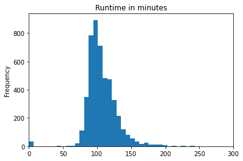

```python
movies[column].plot(kind='hist', bins = 50, xlim=(0,300), title= "Runtime in minutes")
```

### Vote average

```python
column = 'vote_average'
```

Laagste beoordeling

```python
movies[column].min()
```

```
0.0
```

Hoogste beoordeling

```python
movies[column].max()
```

```
10.0
```

Gemiddelde beoordeling van alle films

```python
round(movies[column].mean(),1)
```

```
6.1
```

Mediaan van de beoordeling van alle films (middelste)

```python
round(movies[column].median(),1)
```

```
6.2
```

Standaard afwijking

```python
round(movies[column].std(),2)
```

```
1.19
```

Film(s) met de hoogste beoordeling

```python
movies[movies[column] == movies[column].max()]
```

|  | budget | genres | homepage | id | keywords | original_language | original_title | overview | popularity | production_companies | production_countries | release_date | revenue | runtime | spoken_languages | status | tagline | title | vote_average | vote_count |
| --- | --- | --- | --- | --- | --- | --- | --- | --- | --- | --- | --- | --- | --- | --- | --- | --- | --- | --- | --- | --- |
| 3519 | 0 | [{"id": 35, "name": "Comedy"}] | NaN | 89861 | [{"id": 131, "name": "italy"}, {"id": 8250, "n... | en | Stiff Upper Lips | Stiff Upper Lips is a broad parody of British ... | 0.356495 | [] | [{"iso_3166_1": "GB", "name": "United Kingdom"... | 1998-06-12 | 0 | 99.0 | [{"iso_639_1": "en", "name": "English"}] | Released | NaN | Stiff Upper Lips | 10.0 | 1 |
| 4045 | 0 | [{"id": 35, "name": "Comedy"}, {"id": 18, "nam... | NaN | 78373 | [{"id": 1415, "name": "small town"}, {"id": 15... | en | Dancer, Texas Pop. 81 | Four guys, best friends, have grown up togethe... | 0.376662 | [{"name": "HSX Films", "id": 4714}, {"name": "... | [{"iso_3166_1": "US", "name": "United States o... | 1998-05-01 | 565592 | 97.0 | [{"iso_639_1": "en", "name": "English"}] | Released | in the middle of nowhere they had everything | Dancer, Texas Pop. 81 | 10.0 | 1 |
| 4247 | 1 | [{"id": 10749, "name": "Romance"}, {"id": 35, ... | NaN | 361505 | [] | en | Me You and Five Bucks | A womanizing yet lovable loser, Charlie, a wai... | 0.094105 | [] | [] | 2015-07-07 | 0 | 90.0 | [] | Released | A story about second, second chances | Me You and Five Bucks | 10.0 | 2 |
| 4662 | 0 | [{"id": 35, "name": "Comedy"}] | NaN | 40963 | [{"id": 10183, "name": "independent film"}] | en | Little Big Top | An aging out of work clown returns to his smal... | 0.092100 | [{"name": "Fly High Films", "id": 24248}] | [{"iso_3166_1": "US", "name": "United States o... | 2006-01-01 | 0 | 0.0 | [{"iso_639_1": "en", "name": "English"}] | Rumored | NaN | Little Big Top | 10.0 | 1 |

Film(s) met de laagste beoordeling

```python
movies[movies[column] == movies[column].min()]
```

|  | budget | genres | homepage | id | keywords | original_language | original_title | overview | popularity | production_companies | production_countries | release_date | revenue | runtime | spoken_languages | status | tagline | title | vote_average | vote_count |
| --- | --- | --- | --- | --- | --- | --- | --- | --- | --- | --- | --- | --- | --- | --- | --- | --- | --- | --- | --- | --- |
| 1464 | 0 | [{"id": 18, "name": "Drama"}, {"id": 80, "name... | NaN | 310706 | [] | en | Black Water Transit | In this action thriller set in post-Katrina Ne... | 0.126738 | [{"name": "Capitol Films", "id": 826}] | [{"iso_3166_1": "US", "name": "United States o... | 2009-05-13 | 0 | 100.0 | [{"iso_639_1": "en", "name": "English"}] | Released | NaN | Black Water Transit | 0.0 | 0 |
| 3669 | 0 | [{"id": 35, "name": "Comedy"}, {"id": 18, "nam... | http://www.romeothemovie.com/ | 113406 | [] | en | Should've Been Romeo | A self-centered, middle-aged pitchman for a po... | 0.407030 | [{"name": "Phillybrook Films", "id": 65147}] | [{"iso_3166_1": "US", "name": "United States o... | 2012-04-28 | 0 | 0.0 | [{"iso_639_1": "en", "name": "English"}] | Released | Even Shakespeare didn't see this one coming. | Should've Been Romeo | 0.0 | 0 |
| 3670 | 0 | [{"id": 10751, "name": "Family"}] | NaN | 447027 | [] | en | Running Forever | After being estranged since her mother's death... | 0.028756 | [{"name": "New Kingdom Pictures", "id": 41671}] | [{"iso_3166_1": "US", "name": "United States o... | 2015-10-27 | 0 | 88.0 | [] | Released | NaN | Running Forever | 0.0 | 0 |
| 3852 | 0 | [{"id": 18, "name": "Drama"}] | NaN | 395766 | [{"id": 11162, "name": "miniseries"}] | en | The Secret | The Secret is the story of a real-life double ... | 0.042346 | [] | [] | 2016-04-29 | 0 | 200.0 | [] | Released | NaN | The Secret | 0.0 | 0 |
| 3855 | 3500000 | [{"id": 99, "name": "Documentary"}] | http://www.timetochoose.com | 370662 | [{"id": 2210, "name": "climate change"}, {"id"... | en | Time to Choose | Academy Award® winning director Charles Fergus... | 1.618138 | [{"name": "Representational Pictures", "id": 8... | [{"iso_3166_1": "US", "name": "United States o... | 2015-09-04 | 0 | 100.0 | [{"iso_639_1": "en", "name": "English"}] | Released | Climate change for good. | Time to Choose | 0.0 | 0 |
| ... | ... | ... | ... | ... | ... | ... | ... | ... | ... | ... | ... | ... | ... | ... | ... | ... | ... | ... | ... | ... |
| 4769 | 0 | [{"id": 28, "name": "Action"}, {"id": 37, "nam... | NaN | 69382 | [] | en | The Legend of God's Gun | A gun-slinging preacher returns to the debauch... | 0.003582 | [] | [] | 2007-07-08 | 0 | 78.0 | [] | Released | NaN | The Legend of God's Gun | 0.0 | 0 |
| 4771 | 0 | [{"id": 27, "name": "Horror"}] | NaN | 220490 | [] | en | Her Cry: La Llorona Investigation | Crew of "Paranormal Legends" went to film thei... | 0.056459 | [] | [] | 2013-04-19 | 0 | 89.0 | [] | Released | NaN | Her Cry: La Llorona Investigation | 0.0 | 0 |
| 4780 | 0 | [{"id": 53, "name": "Thriller"}, {"id": 80, "n... | NaN | 366967 | [] | en | Dutch Kills | A desperate ex-con is forced to gather his old... | 0.038143 | [] | [] | 2015-10-02 | 0 | 90.0 | [] | Released | NaN | Dutch Kills | 0.0 | 0 |
| 4785 | 0 | [{"id": 18, "name": "Drama"}] | NaN | 287625 | [] | en | Stories of Our Lives | Created by the members of a Nairobi-based arts... | 0.327794 | [] | [{"iso_3166_1": "KE", "name": "Kenya"}] | 2014-09-05 | 0 | 60.0 | [{"iso_639_1": "sw", "name": "Kiswahili"}, {"i... | Released | NaN | Stories of Our Lives | 0.0 | 0 |
| 4794 | 0 | [{"id": 53, "name": "Thriller"}, {"id": 27, "n... | NaN | 286939 | [] | en | Sanctuary: Quite a Conundrum | It should have been just a normal day of sex, ... | 0.166513 | [{"name": "Gold Lion Films", "id": 37870}, {"n... | [{"iso_3166_1": "US", "name": "United States o... | 2012-01-20 | 0 | 82.0 | [{"iso_639_1": "en", "name": "English"}] | Released | NaN | Sanctuary: Quite a Conundrum | 0.0 | 0 |

63 rows × 20 columns

Top 5 films met de hoogste- en laagste beoordeling

```python
movies.sort_values(by="vote_average")
```

|  | budget | genres | homepage | id | keywords | original_language | original_title | overview | popularity | production_companies | production_countries | release_date | revenue | runtime | spoken_languages | status | tagline | title | vote_average | vote_count |
| --- | --- | --- | --- | --- | --- | --- | --- | --- | --- | --- | --- | --- | --- | --- | --- | --- | --- | --- | --- | --- |
| 4633 | 0 | [] | NaN | 300327 | [] | en | Death Calls | An action-packed love story on the Mexican bor... | 0.005883 | [] | [] | 2010-09-01 | 0 | 0.0 | [] | Released | NaN | Death Calls | 0.0 | 0 |
| 4305 | 0 | [{"id": 35, "name": "Comedy"}, {"id": 10402, "... | NaN | 114065 | [] | en | Down & Out With The Dolls | The raunchy, spunky tale of the rise and fall ... | 0.002386 | [] | [] | 2003-03-20 | 0 | 88.0 | [] | Released | Ain't Rock 'N' Roll a bitch. | Down & Out With The Dolls | 0.0 | 0 |
| 4653 | 0 | [{"id": 18, "name": "Drama"}] | NaN | 46252 | [] | en | Rust | In the midst of a midlife crisis of faith, a m... | 0.399491 | [] | [] | 2010-10-07 | 0 | 94.0 | [] | Released | NaN | Rust | 0.0 | 0 |
| 4293 | 1 | [] | http://thealgerianmovie.com/ | 357834 | [] | en | The Algerian | The Algerian is an international political thr... | 0.025364 | [{"name": "Zelko Films", "id": 62451}] | [{"iso_3166_1": "DZ", "name": "Algeria"}, {"is... | 2015-08-07 | 0 | 99.0 | [] | Released | NaN | The Algerian | 0.0 | 0 |
| 4118 | 0 | [] | NaN | 325140 | [] | en | Hum To Mohabbat Karega | Raju, a waiter, is in love with the famous TV ... | 0.001186 | [] | [] | 2000-05-26 | 0 | 0.0 | [] | Released | NaN | Hum To Mohabbat Karega | 0.0 | 0 |
| ... | ... | ... | ... | ... | ... | ... | ... | ... | ... | ... | ... | ... | ... | ... | ... | ... | ... | ... | ... | ... |
| 3992 | 0 | [] | NaN | 346081 | [] | en | Sardaarji | A ghost hunter uses bottles to capture trouble... | 0.296981 | [] | [{"iso_3166_1": "IN", "name": "India"}] | 2015-06-26 | 0 | 0.0 | [] | Released | NaN | Sardaarji | 9.5 | 2 |
| 3519 | 0 | [{"id": 35, "name": "Comedy"}] | NaN | 89861 | [{"id": 131, "name": "italy"}, {"id": 8250, "n... | en | Stiff Upper Lips | Stiff Upper Lips is a broad parody of British ... | 0.356495 | [] | [{"iso_3166_1": "GB", "name": "United Kingdom"... | 1998-06-12 | 0 | 99.0 | [{"iso_639_1": "en", "name": "English"}] | Released | NaN | Stiff Upper Lips | 10.0 | 1 |
| 4045 | 0 | [{"id": 35, "name": "Comedy"}, {"id": 18, "nam... | NaN | 78373 | [{"id": 1415, "name": "small town"}, {"id": 15... | en | Dancer, Texas Pop. 81 | Four guys, best friends, have grown up togethe... | 0.376662 | [{"name": "HSX Films", "id": 4714}, {"name": "... | [{"iso_3166_1": "US", "name": "United States o... | 1998-05-01 | 565592 | 97.0 | [{"iso_639_1": "en", "name": "English"}] | Released | in the middle of nowhere they had everything | Dancer, Texas Pop. 81 | 10.0 | 1 |
| 4247 | 1 | [{"id": 10749, "name": "Romance"}, {"id": 35, ... | NaN | 361505 | [] | en | Me You and Five Bucks | A womanizing yet lovable loser, Charlie, a wai... | 0.094105 | [] | [] | 2015-07-07 | 0 | 90.0 | [] | Released | A story about second, second chances | Me You and Five Bucks | 10.0 | 2 |
| 4662 | 0 | [{"id": 35, "name": "Comedy"}] | NaN | 40963 | [{"id": 10183, "name": "independent film"}] | en | Little Big Top | An aging out of work clown returns to his smal... | 0.092100 | [{"name": "Fly High Films", "id": 24248}] | [{"iso_3166_1": "US", "name": "United States o... | 2006-01-01 | 0 | 0.0 | [{"iso_639_1": "en", "name": "English"}] | Rumored | NaN | Little Big Top | 10.0 | 1 |

4803 rows × 20 columns

Histogram van de gemiddelde beoordeling

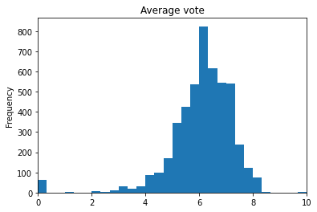

```python
movies[column].plot(kind='hist', bins = 30, xlim=(0,10), title= "Average vote")
```

### Budget

```python
column = 'budget'
```

Kleinste budget

```python
movies[column].min()
```

[output not shown]

Grootste budget

```python
movies[column].max()
```

[output not shown]

Gemiddelde budget

```python
round(movies[column].mean())
```

[output not shown]

Mediaan van budget (middelste)

```python
round(movies[column].median())
```

[output not shown]

Standaard afwijking

```python
round(movies[column].std())
```

[output not shown]

Film(s) met het grootste budget

```python
movies[movies[column] == movies[column].max()]
```

[output not shown]

Film(s) met het kleinste budget

```python
movies[movies[column] == movies[column].min()]
```

[output not shown]

Histogram van de budgets van alle films

[figure not shown]

```python
movies[column].plot(kind='hist', bins =50, xlim=(0), title= "Budget in millions")
```

```python
movies['status'].value_counts().plot(kind='barh', title='Movie status', legend= True)
```

[output not shown]